# PCA, annotation, fgsea, and target venn diagrams

KRG

7/13/2020

## unfiltered PCA of all samples (Figure S3D)

input file “final_samples_KRG.txt” is available in my [Github](https://github.com/kathrynrozengagnon/AGOCLIP_2020) input file “KRG_all_final_peaksDF_finalGRs_rename.txt” was generated from *Processing_to_matrix* script and is available in my [Github](https://github.com/kathrynrozengagnon/AGOCLIP_2020)

```r
#read in all peaks from matrix building; input file is peak matrix with boolean for whether or not a peak was called, and the counts overlapping the peak ranges, by sample, generated in the processing script
all <- read.delim("/Users/kathryn/Reprocess_all_paper_datasets/KRG_all_final_peaksDF_finalGRs_rename.txt", header = TRUE, sep = "\t")

all_samples <- read.delim("/Users/kathryn/Reprocess_all_paper_datasets/final_samples_KRG.txt", header = TRUE, sep = "\t")

row.names(all_samples) <- all_samples$X
all_samples <- all_samples[,2:4]
m_all <- row.names(all_samples)
colnames(all) <- gsub("_rm5_rm3.bed", "", colnames(all))
row.names(all) <- all$peakID

#check that sample names match
m_all %in% colnames(all)
```

```
##  [1] TRUE TRUE TRUE TRUE TRUE TRUE TRUE TRUE TRUE TRUE TRUE TRUE TRUE TRUE
## [15] TRUE TRUE TRUE TRUE TRUE TRUE TRUE TRUE TRUE TRUE TRUE TRUE TRUE TRUE
## [29] TRUE TRUE TRUE TRUE TRUE TRUE TRUE TRUE TRUE TRUE TRUE TRUE TRUE TRUE
## [43] TRUE TRUE TRUE TRUE TRUE TRUE TRUE TRUE TRUE TRUE TRUE TRUE TRUE TRUE
## [57] TRUE TRUE TRUE TRUE TRUE TRUE TRUE TRUE TRUE TRUE TRUE TRUE TRUE TRUE
## [71] TRUE TRUE TRUE TRUE TRUE TRUE TRUE TRUE TRUE TRUE TRUE TRUE TRUE TRUE
## [85] TRUE TRUE TRUE TRUE TRUE TRUE TRUE TRUE TRUE TRUE TRUE TRUE TRUE
```

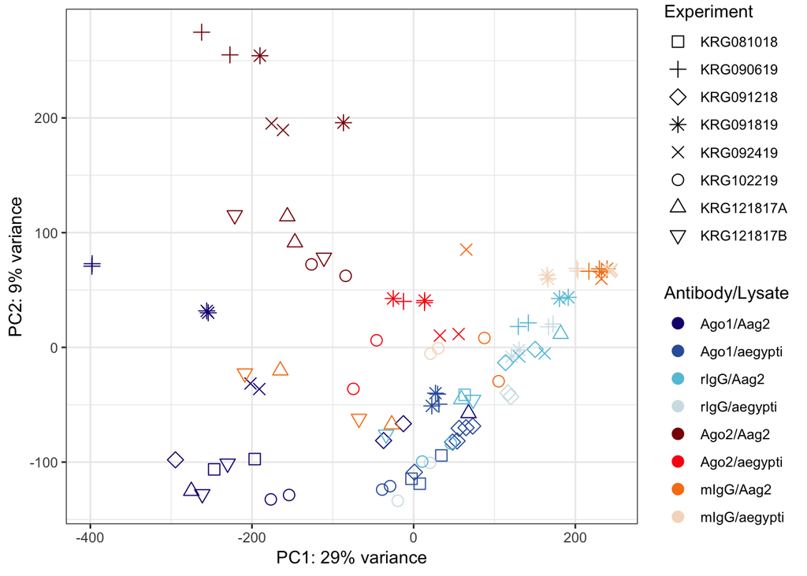

```r
all_x <- all[m_all]

dds_all <- DESeqDataSetFromMatrix(countData = all_x, colData = all_samples, design = ~ Experiment + Antibody + Lysate)

dds_all <- estimateSizeFactors(dds_all,type="poscounts")

rld_all <- varianceStabilizingTransformation(dds_all)

p <-  plotPCA(rld_all,intgroup=c("Experiment", "Antibody", "Lysate"), ntop=10^6, returnData=TRUE)

#reorder/rename levels so can set colors/shapes
p$group <- paste0(p$Antibody, "/", p$Lysate)
p$group <- as.factor(p$group)
p$group <- factor(p$group, levels = c("Ago1/Aag2", "Ago1/aegypti","rIgG/Aag2", "rIgG/aegypti", "Ago2/Aag2","Ago2/aegypti", "mIgG/Aag2","mIgG/aegypti"))

#set PC1 direction to be consistent with subsequent PCAs
p$PC1 <- (p$PC1)*-1
#calculate variation as a rounded percent
percentVar <- round(100 * attr(p, "percentVar"))

ggplot(p, aes(x = PC1, y = PC2, color = group, shape = Experiment, label=name)) +
geom_point(size =3) +
scale_shape_manual(values=c(0,3,5, 8, 4,1, 2, 6)) +
scale_color_manual(values =c("#1B0B80", "#3360A9",  "#64C3DB", "#D2E1E5", "#8A0F09","#FA0F0C", "#F87F11", "#F4DBC7"), name="Antibody/Lysate") +
xlab(paste0("PC1: ", percentVar[1], "% variance")) +
ylab(paste0("PC2: ", percentVar[2], "% variance")) + theme_bw()
```

## Annotate and filter for PCA calculations

input gtf file used to be available for download at [Vectorbase](https://vectorbase.org/vectorbase/app/downloads/) However, I am unsure if the gtf file is still available there; it is too large to upload to Github, but is available upon request

```r
gtffile <- "/Users/kathryn/Aedes-aegypti-LVP_AGWG_BASEFEATURES_AaegL5.2.gtf"

TxDb <- makeTxDbFromGFF(gtffile)
```

```
## Import genomic features from the file as a GRanges object ... OK
## Prepare the 'metadata' data frame ... OK
## Make the TxDb object ...
```

```
## OK
```

```r
allGR <- makeGRangesFromDataFrame(all,
                                     keep.extra.columns=FALSE,
                                     ignore.strand=FALSE,
                                     seqinfo=NULL,
                                     seqnames.field="seqnames",
                                     start.field="start",
                                     end.field="end",
                                     strand.field="strand",
                                     starts.in.df.are.0based=FALSE)

allanno <- annotatePeak(allGR,
                              TxDb=TxDb,
                              sameStrand=FALSE,
                              genomicAnnotationPriority = c("3UTR", "5UTR", "Exon",
                                                            "Intron", "Promoter", "Downstream", "Intergenic"),
                              overlap = "all")
```

```
## >> preparing features information...      2021-03-16 17:11:40
## >> identifying nearest features...        2021-03-16 17:11:40
```

```
## >> calculating distance from peak to TSS...   2021-03-16 17:11:44
## >> assigning genomic annotation...        2021-03-16 17:11:44
```

```
## >> assigning chromosome lengths           2021-03-16 17:11:48
## >> done...                    2021-03-16 17:11:48
```

```r
allannodf <- as.data.frame(allanno)

allannodf$peakID <- paste0(allannodf$seqnames, ":", allannodf$start, "_", allannodf$end, ":", allannodf$strand)

v <- merge(all, allannodf[,c(6:15)], by="peakID", all.x=TRUE)
all <- v

#get peak biological complexity (BC) - in how many samples by antibody/lysate was a peak called

#first define boolean columns, with TRUE/FALSE if the peak was called in that sample
bool <- grep("*.txt", colnames(all), value = TRUE)

temp <- strsplit(bool, "_")
mat  <- matrix(unlist(temp), ncol=6, byrow=TRUE)
mat <- mat[,2:3]
df <- cbind(bool, mat)
col.names <- c("name", "Lysate", "Antibody")
df <- as.data.frame(df)
df <- setNames(df, col.names)
df$group <- paste0(df$Lysate, df$Antibody)
df_group <- df %>% group_by(group)
df_group$name <- as.character(df_group$name)
aegyptiAgo1 <- subset(df_group$name, df_group$group == "aegyptiAgo1")
aegyptiAgo2 <- subset(df_group$name, df_group$group == "aegyptiAgo2")
aegyptirIgG <- subset(df_group$name, df_group$group == "aegyptirIgG")
aegyptimIgG <- subset(df_group$name, df_group$group == "aegyptimIgG")
Aag2Ago1 <- subset(df_group$name, df_group$group == "Aag2Ago1")
Aag2Ago2 <- subset(df_group$name, df_group$group == "Aag2Ago2")
Aag2rIgG <- subset(df_group$name, df_group$group == "Aag2rIgG")
Aag2mIgG <- subset(df_group$name, df_group$group == "Aag2mIgG")

#then count peakBC
all$aegyptiAgo1_peakBC <- rowSums(all[aegyptiAgo1])
all$aegyptiAgo2_peakBC <- rowSums(all[aegyptiAgo2])
all$aegyptirIgG_peakBC <- rowSums(all[aegyptirIgG])
all$aegyptimIgG_peakBC <- rowSums(all[aegyptimIgG])
all$Aag2Ago1_peakBC <- rowSums(all[Aag2Ago1])
all$Aag2Ago2_peakBC <- rowSums(all[Aag2Ago2])
all$Aag2rIgG_peakBC <- rowSums(all[Aag2rIgG])
all$Aag2mIgG_peakBC <- rowSums(all[Aag2mIgG])

#define read count columns, which contain raw read counts at each peak region by sample
aegyptiAgo1b <- gsub("_rm5_rm3.txt", "", aegyptiAgo1)
aegyptiAgo2b <- gsub("_rm5_rm3.txt", "", aegyptiAgo2)
aegyptirIgGb <- gsub("_rm5_rm3.txt", "", aegyptirIgG)
aegyptimIgGb <- gsub("_rm5_rm3.txt", "", aegyptimIgG)
Aag2Ago1b <- gsub("_rm5_rm3.txt", "", Aag2Ago1)
Aag2Ago2b <- gsub("_rm5_rm3.txt", "", Aag2Ago2)
Aag2rIgGb <- gsub("_rm5_rm3.txt", "",Aag2rIgG)
Aag2mIgGb <- gsub("_rm5_rm3.txt", "", Aag2mIgG)

#get total counts by antibody/lysate
all$aegyptiAgo1_counts <- rowSums(all[aegyptiAgo1b])
all$aegyptiAgo2_counts <- rowSums(all[aegyptiAgo2b])
all$aegyptirIgG_counts <- rowSums(all[aegyptirIgGb])
all$aegyptimIgG_counts <- rowSums(all[aegyptimIgGb])
all$Aag2Ago1_counts <- rowSums(all[Aag2Ago1b])
all$Aag2Ago2_counts <- rowSums(all[Aag2Ago2b])
all$Aag2rIgG_counts <- rowSums(all[Aag2rIgGb])
all$Aag2mIgG_counts <- rowSums(all[Aag2mIgGb])

#get normalized counts in reads per million mapped (in peaks)
all$aegyptiAgo1_counts_norm <- (all$aegyptiAgo1_counts)/(sum(all$aegyptiAgo1_counts))*1E6
all$aegyptiAgo2_counts_norm <- (all$aegyptiAgo2_counts)/(sum(all$aegyptiAgo2_counts))*1E6
all$aegyptirIgG_counts_norm <- (all$aegyptirIgG_counts)/(sum(all$aegyptirIgG_counts))*1E6
all$aegyptimIgG_counts_norm <- (all$aegyptimIgG_counts)/(sum(all$aegyptimIgG_counts))*1E6
all$Aag2Ago1_counts_norm <- (all$Aag2Ago1_counts)/(sum(all$Aag2Ago1_counts))*1E6
all$Aag2Ago2_counts_norm <- (all$Aag2Ago2_counts)/(sum(all$Aag2Ago2_counts))*1E6
all$Aag2rIgG_counts_norm <- (all$Aag2rIgG_counts)/(sum(all$Aag2rIgG_counts))*1E6
all$Aag2mIgG_counts_norm <- (all$Aag2mIgG_counts)/(sum(all$Aag2mIgG_counts))*1E6

#Specific ab > 10X higher than IgG (norm counts)
all$aegypti_Ago1_over_rIgG <- ifelse(all$aegyptiAgo1_counts_norm >= (10 * all$aegyptirIgG_counts_norm), paste0("TRUE"), paste0("FALSE"))
all$aegypti_Ago1_over_rIgG <- ifelse(all$aegyptiAgo1_counts_norm == all$aegyptirIgG_counts_norm, paste0("FALSE"), paste0(all$aegypti_Ago1_over_rIgG))

all$aegypti_Ago2_over_mIgG <- ifelse(all$aegyptiAgo2_counts_norm >= (10 * all$aegyptimIgG_counts_norm), paste0("TRUE"), paste0("FALSE"))
all$aegypti_Ago2_over_mIgG <- ifelse(all$aegyptiAgo2_counts_norm == all$aegyptimIgG_counts_norm, paste0("FALSE"), paste0(all$aegypti_Ago2_over_mIgG))

all$Aag2_Ago1_over_rIgG <- ifelse(all$Aag2Ago1_counts_norm >= (10 * all$Aag2rIgG_counts_norm), paste0("TRUE"), paste0("FALSE"))
all$Aag2_Ago1_over_rIgG <- ifelse(all$Aag2Ago1_counts_norm == all$Aag2rIgG_counts_norm, paste0("FALSE"), paste0(all$Aag2_Ago1_over_rIgG))

all$Aag2_Ago2_over_mIgG <- ifelse(all$Aag2Ago2_counts_norm >= (10 * all$Aag2mIgG_counts_norm), paste0("TRUE"), paste0("FALSE"))
all$Aag2_Ago2_over_mIgG <- ifelse(all$Aag2Ago2_counts_norm == all$Aag2mIgG_counts_norm, paste0("FALSE"), paste0(all$Aag2_Ago2_over_mIgG))

#get the number of samples with a raw read count equal to or greater than 10 at each peak location, by antibody/lysate
all$Aag2_Ago1_nhipeaks <- apply(all[Aag2Ago1b], 1, function(x) length(which(x>=10)))
all$Aag2_Ago2_nhipeaks <- apply(all[Aag2Ago2b], 1, function(x) length(which(x>=10)))
all$Aag2_rIgG_nhipeaks <- apply(all[Aag2rIgGb], 1, function(x) length(which(x>=10)))
all$Aag2_mIgG_nhipeaks <- apply(all[Aag2mIgGb], 1, function(x) length(which(x>=10)))
all$aegypti_Ago1_nhipeaks <- apply(all[aegyptiAgo1b], 1, function(x) length(which(x>=10)))
all$aegypti_Ago2_nhipeaks <- apply(all[aegyptiAgo2b], 1, function(x) length(which(x>=10)))
all$aegypti_rIgG_nhipeaks <- apply(all[aegyptirIgGb], 1, function(x) length(which(x>=10)))
all$aegypti_mIgG_nhipeaks <- apply(all[aegyptimIgGb], 1, function(x) length(which(x>=10)))

#get the number of samples with at least one read at each peak location, by antibody/lysate
all$aegypti_Ago1_BCsample <- apply(all[aegyptiAgo1b], 1, function(x) length(which(x>0)))
all$aegypti_Ago2_BCsample <- apply(all[aegyptiAgo2b], 1, function(x) length(which(x>0)))
all$aegypti_rIgG_BCsample <- apply(all[aegyptirIgGb], 1, function(x) length(which(x>0)))
all$aegypti_mIgG_BCsample <- apply(all[aegyptimIgGb], 1, function(x) length(which(x>0)))
all$Aag2_Ago1_BCsample <- apply(all[Aag2Ago1b], 1, function(x) length(which(x>0)))
all$Aag2_Ago2_BCsample <- apply(all[Aag2Ago2b], 1, function(x) length(which(x>0)))
all$Aag2_rIgG_BCsample <- apply(all[Aag2rIgGb], 1, function(x) length(which(x>0)))
all$Aag2_mIgG_BCsample <- apply(all[Aag2mIgGb], 1, function(x) length(which(x>0)))

#write.table(all, "/Users/kathryn/Reprocess_all_paper_datasets/Supp_Figs/Final_matrix_all_peaks_add_filtering.txt", col.names = TRUE, row.names = FALSE, quote = FALSE, sep = "\t")
```

output file is available in my [Github](https://github.com/kathrynrozengagnon/AGOCLIP_2020)

## Test filtering conditions,Figure S3A-S3C

```r
#check porportion of 3'UTRs for Ago1

f <- subset(all, all$aegyptiAgo1_peakBC > 0)
y <- subset(all, all$aegyptirIgG_peakBC > 0)
a <- subset(all, all$Aag2Ago1_peakBC > 0)
b <- subset(all, all$Aag2rIgG_peakBC > 0)
ls <- mget(c("f", "y", "a","b"), envir = globalenv())
ls <- lapply(ls, function(x) x <- x[,c("annotation")])
names(ls) <- c("aegyptiAgo1", "aegyptirIgG", "Aag2Ago1", "Aag2rIgG")

BC_UTRfun <- function(x) {
UTR3 <- length(which(x=="3' UTR"))
pUTR3 <- UTR3/(length(x))
print(pUTR3)
}

ann_mat <- vector("list", length(ls))
for(i in 1:length(ls)){
 ann_mat[i] <- BC_UTRfun(ls[[i]])
 ann_mat[[i]] <- as.data.frame(ann_mat[[i]])
 names(ann_mat[[i]]) <- "one_peak"
}
```

```
## [1] 0.1617916
## [1] 0.08659379
## [1] 0.2276189
## [1] 0.02848229
```

```r
names(ann_mat) <- names(ls)


f <- subset(all, all$aegyptiAgo1_peakBC > 0 & all$aegypti_Ago1_over_rIgG == TRUE)
y <- subset(all, all$aegyptirIgG_peakBC > 0 & all$aegypti_Ago1_over_rIgG == FALSE)
a <- subset(all, all$Aag2Ago1_peakBC > 0 & all$Aag2_Ago1_over_rIgG == TRUE)
b <- subset(all, all$Aag2rIgG_peakBC > 0 & all$Aag2_Ago1_over_rIgG == FALSE)

ls <- mget(c("f", "y", "a","b"), envir = globalenv())
names(ls) <- c("aegypti_Ago1", "aegypti_rIgG", "Aag2_Ago1", "Aag2_rIgG")

temp <- vector("list", length(ls))
for(i in 1:length(ls)){
temp[[i]] <- ls[[i]][,c("annotation", c(paste0(names(ls[i]), "_nhipeaks")))]
}
names(temp) <- c("aegypti_Ago1", "aegypti_rIgG", "Aag2_Ago1", "Aag2_rIgG")

bb  <- vector("list", length(ls))
for(i in 1:length(ls)){
 bb[i] <- BC_UTRfun(ls[[i]]$annotation)
bb[[i]] <- as.data.frame(bb[[i]])
 names(bb[[i]]) <- "plus_over_IgG"
 ann_mat[[i]] <- bind_cols(ann_mat[[i]], bb[[i]])
}
```

```
## [1] 0.1579173
## [1] 0.08671852
## [1] 0.2571187
## [1] 0.02839879
```

```r
BC_UTRfun_nhi <- function(x, nhi) {
x <- subset(x, x[,2] >= nhi)
UTR3 <- length(which(x$annotation=="3' UTR"))
pUTR3 <- UTR3/(nrow(x))
print(pUTR3)
}

bb  <- vector("list", length(temp))
for(i in 1:length(temp)){
 bb[i] <- BC_UTRfun_nhi(temp[[i]], 1)
bb[[i]] <- as.data.frame(bb[[i]])
 names(bb[[i]]) <- "plus_1nhi"
 ann_mat[[i]] <- bind_cols(ann_mat[[i]], bb[[i]])
}
```

```
## [1] 0.1554716
## [1] 0.03561767
## [1] 0.2971645
## [1] 0.02457703
```

```r
bb  <- vector("list", length(temp))
for(i in 1:length(temp)){
 bb[i] <- BC_UTRfun_nhi(temp[[i]], 2)
bb[[i]] <- as.data.frame(bb[[i]])
 names(bb[[i]]) <- "plus_2nhi"
 ann_mat[[i]] <- bind_cols(ann_mat[[i]], bb[[i]])
}
```

```
## [1] 0.2339527
## [1] 0.008135593
## [1] 0.4175992
## [1] 0.009321595
```

```r
ann_mat <- rbindlist(ann_mat, idcol = TRUE)
#write.table(ann_mat, "/Users/kathryn/Reprocess_all_paper_datasets/Supp_Figs/Ago1_3UTR_enrichment_filtering.txt", col.names = TRUE, row.names = FALSE, quote = FALSE, sep ="\t")

##3'UTR Ago2
f <- subset(all, all$aegyptiAgo2_peakBC > 0)
y <- subset(all, all$aegyptimIgG_peakBC > 0)
a <- subset(all, all$Aag2Ago2_peakBC > 0)
b <- subset(all, all$Aag2mIgG_peakBC > 0)
ls <- mget(c("f", "y", "a","b"), envir = globalenv())
ls <- lapply(ls, function(x) x <- x[,c("annotation")])
names(ls) <- c("aegypti_Ago2", "aegypti_mIgG", "Aag2_Ago2", "Aag2_mIgG")

ann_mat <- vector("list", length(ls))
for(i in 1:length(ls)){
 ann_mat[i] <- BC_UTRfun(ls[[i]])
 ann_mat[[i]] <- as.data.frame(ann_mat[[i]])
 names(ann_mat[[i]]) <- "one_peak"
}
```

```
## [1] 0.1673181
## [1] 0.03061224
## [1] 0.08509174
## [1] 0.09986301
```

```r
names(ann_mat) <- names(ls)


f <- subset(all, all$aegyptiAgo2_peakBC > 0 & all$aegypti_Ago2_over_mIgG == TRUE)
y <- subset(all, all$aegyptimIgG_peakBC > 0 & all$aegypti_Ago2_over_mIgG == FALSE)
a <- subset(all, all$Aag2Ago2_peakBC > 0 & all$Aag2_Ago2_over_mIgG == TRUE)
b <- subset(all, all$Aag2mIgG_peakBC > 0 & all$Aag2_Ago2_over_mIgG == FALSE)

ls <- mget(c("f", "y", "a","b"), envir = globalenv())
names(ls) <- c("aegypti_Ago2", "aegypti_mIgG", "Aag2_Ago2", "Aag2_mIgG")

temp <- vector("list", length(ls))
for(i in 1:length(ls)){
temp[[i]] <- ls[[i]][,c("annotation", c(paste0(names(ls[i]), "_nhipeaks")))]
}
names(temp) <- c("aegypti_Ago2", "aegypti_mIgG", "Aag2_Ago2", "Aag2_mIgG")

bb  <- vector("list", length(ls))
for(i in 1:length(ls)){
 bb[i] <- BC_UTRfun(ls[[i]]$annotation)
bb[[i]] <- as.data.frame(bb[[i]])
 names(bb[[i]]) <- "plus_over_IgG"
 ann_mat[[i]] <- bind_cols(ann_mat[[i]], bb[[i]])
}
```

```
## [1] 0.271442
## [1] 0.02923977
## [1] 0.06371104
## [1] 0.10022
```

```r
bb  <- vector("list", length(temp))
for(i in 1:length(temp)){
 bb[i] <- BC_UTRfun_nhi(temp[[i]], 1)
bb[[i]] <- as.data.frame(bb[[i]])
 names(bb[[i]]) <- "plus_1nhi"
 ann_mat[[i]] <- bind_cols(ann_mat[[i]], bb[[i]])
}
```

```
## [1] 0.3562775
## [1] 0.01410935
## [1] 0.05051195
## [1] 0.06243423
```

```r
bb  <- vector("list", length(temp))
for(i in 1:length(temp)){
 bb[i] <- BC_UTRfun_nhi(temp[[i]], 2)
bb[[i]] <- as.data.frame(bb[[i]])
 names(bb[[i]]) <- "plus_2nhi"
 ann_mat[[i]] <- bind_cols(ann_mat[[i]], bb[[i]])
}
```

```
## [1] 0.3982558
## [1] 0.004932182
## [1] 0.04627072
## [1] 0.03746531
```

```r
ann_mat <- rbindlist(ann_mat, idcol = TRUE)
#write.table(ann_mat, "/Users/kathryn/Reprocess_all_paper_datasets/Supp_Figs/Ago2_3UTR_enrichment_filtering.txt", col.names = TRUE, row.names = FALSE, quote = FALSE, sep ="\t")


##Distal Intergenic Ago2
f <- subset(all, all$aegyptiAgo2_peakBC > 0)
y <- subset(all, all$aegyptimIgG_peakBC > 0)
a <- subset(all, all$Aag2Ago2_peakBC > 0)
b <- subset(all, all$Aag2mIgG_peakBC > 0)
ls <- mget(c("f", "y", "a","b"), envir = globalenv())
ls <- lapply(ls, function(x) x <- x[,c("annotation")])
names(ls) <- c("aegypti_Ago2", "aegypti_mIgG", "Aag2_Ago2", "Aag2_mIgG")

BC_DIfun <- function(x) {
DI <- length(which(x=="Distal Intergenic"))
pDI <- DI/(length(x))
print(pDI)
}

ann_mat <- vector("list", length(ls))
for(i in 1:length(ls)){
 ann_mat[i] <- BC_DIfun(ls[[i]])
 ann_mat[[i]] <- as.data.frame(ann_mat[[i]])
 names(ann_mat[[i]]) <- "one_peak"
}
```

```
## [1] 0.1258268
## [1] 0.1895044
## [1] 0.2841055
## [1] 0.2020548
```

```r
names(ann_mat) <- names(ls)


f <- subset(all, all$aegyptiAgo2_peakBC > 0 & all$aegypti_Ago2_over_mIgG == TRUE)
y <- subset(all, all$aegyptimIgG_peakBC > 0 & all$aegypti_Ago2_over_mIgG == FALSE)
a <- subset(all, all$Aag2Ago2_peakBC > 0 & all$Aag2_Ago2_over_mIgG == TRUE)
b <- subset(all, all$Aag2mIgG_peakBC > 0 & all$Aag2_Ago2_over_mIgG == FALSE)

ls <- mget(c("f", "y", "a","b"), envir = globalenv())
names(ls) <- c("aegypti_Ago2", "aegypti_mIgG", "Aag2_Ago2", "Aag2_mIgG")

temp <- vector("list", length(ls))
for(i in 1:length(ls)){
temp[[i]] <- ls[[i]][,c("annotation", c(paste0(names(ls[i]), "_nhipeaks")))]
}
names(temp) <- c("aegypti_Ago2", "aegypti_mIgG", "Aag2_Ago2", "Aag2_mIgG")

bb  <- vector("list", length(ls))
for(i in 1:length(ls)){
 bb[i] <- BC_DIfun(ls[[i]]$annotation)
bb[[i]] <- as.data.frame(bb[[i]])
 names(bb[[i]]) <- "plus_over_IgG"
 ann_mat[[i]] <- bind_cols(ann_mat[[i]], bb[[i]])
}
```

```
## [1] 0.1131008
## [1] 0.1900585
## [1] 0.3134478
## [1] 0.2016772
```

```r
BC_DIfun_nhi <- function(x, nhi) {
x <- subset(x, x[,2] >= nhi)
DI <- length(which(x=="Distal Intergenic"))
pDI <- DI/(length(x))
print(pDI)
}

bb  <- vector("list", length(temp))
for(i in 1:length(temp)){
 bb[i] <- BC_UTRfun_nhi(temp[[i]], 1)
bb[[i]] <- as.data.frame(bb[[i]])
 names(bb[[i]]) <- "plus_1nhi"
 ann_mat[[i]] <- bind_cols(ann_mat[[i]], bb[[i]])
}
```

```
## [1] 0.3562775
## [1] 0.01410935
## [1] 0.05051195
## [1] 0.06243423
```

```r
bb  <- vector("list", length(temp))
for(i in 1:length(temp)){
 bb[i] <- BC_DIfun_nhi(temp[[i]], 2)
bb[[i]] <- as.data.frame(bb[[i]])
 names(bb[[i]]) <- "plus_2nhi"
 ann_mat[[i]] <- bind_cols(ann_mat[[i]], bb[[i]])
}
```

```
## [1] 12.5
## [1] 41
## [1] 339.5
## [1] 139
```

```r
ann_mat <- rbindlist(ann_mat, idcol = TRUE)
#write.table(ann_mat, "/Users/kathryn/Reprocess_all_paper_datasets/Supp_Figs/Ago2_distal_intergenic_enrichment_filtering.txt", col.names = TRUE, row.names = FALSE, quote = FALSE, sep ="\t")

#final filtering: peakBC > 0 and Ab is 10X above sample, nhi = 2 or more
#Ago1 and Ago2 sets together for PCA:
Aag2 <- subset(all, all$Aag2Ago1_peakBC > 0 & all$Aag2_Ago1_nhipeaks > 1 & all$Aag2_Ago1_over_rIgG == "TRUE" | all$Aag2Ago2_peakBC > 0 & all$Aag2_Ago2_nhipeaks > 1 & all$Aag2_Ago2_over_mIgG == "TRUE")
row.names(Aag2) <- Aag2$peakID

aegypti <- subset(all, all$aegyptiAgo1_peakBC > 0 & all$aegypti_Ago1_nhipeaks > 1 & all$aegypti_Ago1_over_rIgG == "TRUE" | all$aegyptiAgo2_peakBC > 0 & all$aegypti_Ago2_nhipeaks > 1 & all$aegypti_Ago2_over_mIgG == "TRUE")
row.names(aegypti) <- aegypti$peakID

#Individual sets
Aag2_Ago1_filt <- subset(all, all$Aag2Ago1_peakBC > 0 & all$Aag2_Ago1_nhipeaks > 1 & all$Aag2_Ago1_over_rIgG == "TRUE")
#write.table(Aag2_Ago1_filt, "/Users/kathryn/Reprocess_all_paper_datasets/Supp_Figs/Final_cells_Ago1_matrix_filtered_peaks.txt", col.names = TRUE, row.names = FALSE, quote= FALSE, sp = "\t")
Aag2_Ago2_filt <- subset(all, all$Aag2Ago2_peakBC > 0 & all$Aag2_Ago2_nhipeaks > 1 & all$Aag2_Ago2_over_mIgG == "TRUE")
#write.table(Aag2_Ago2_filt, "/Users/kathryn/Reprocess_all_paper_datasets/Supp_Figs/Final_cells_Ago2_matrix_filtered_peaks.txt", col.names = TRUE, row.names = FALSE, quote= FALSE, sp = "\t")

aegypti_Ago1_filt <- subset(all, all$aegyptiAgo1_peakBC > 0 & all$aegypti_Ago1_nhipeaks > 1 & all$aegypti_Ago1_over_rIgG == "TRUE")
#write.table(aegypti_Ago1_filt , "/Users/kathryn/Reprocess_all_paper_datasets/Supp_Figs/Final_aegypti_Ago1_matrix_filtered_peaks.txt", col.names = TRUE, row.names = FALSE, quote= FALSE, sp = "\t")
aegypti_Ago2_filt <- subset(all, all$aegyptiAgo2_peakBC > 0 & all$aegypti_Ago2_nhipeaks > 1 & all$aegypti_Ago2_over_mIgG == "TRUE")
#write.table(aegypti_Ago2_filt , "/Users/kathryn/Reprocess_all_paper_datasets/Supp_Figs/Final_aegypti_Ago2_matrix_filtered_peaks.txt", col.names = TRUE, row.names = FALSE, quote= FALSE, sp = "\t")
```

output files are available in my [Github](https://github.com/kathrynrozengagnon/AGOCLIP_2020)

## Cells PCA, Figure 4G

```r
cell_samples <- subset(all_samples, all_samples$Lysate=="Aag2")
cell_samples$Lysate <- NULL

m_cells <- row.names(cell_samples)
#check that sample names match
m_cells %in% colnames(Aag2)
```

```
##  [1] TRUE TRUE TRUE TRUE TRUE TRUE TRUE TRUE TRUE TRUE TRUE TRUE TRUE TRUE
## [15] TRUE TRUE TRUE TRUE TRUE TRUE TRUE TRUE TRUE TRUE TRUE TRUE TRUE TRUE
## [29] TRUE TRUE TRUE TRUE TRUE TRUE TRUE TRUE TRUE TRUE TRUE TRUE TRUE TRUE
## [43] TRUE TRUE TRUE TRUE TRUE TRUE TRUE TRUE TRUE TRUE TRUE TRUE TRUE TRUE
```

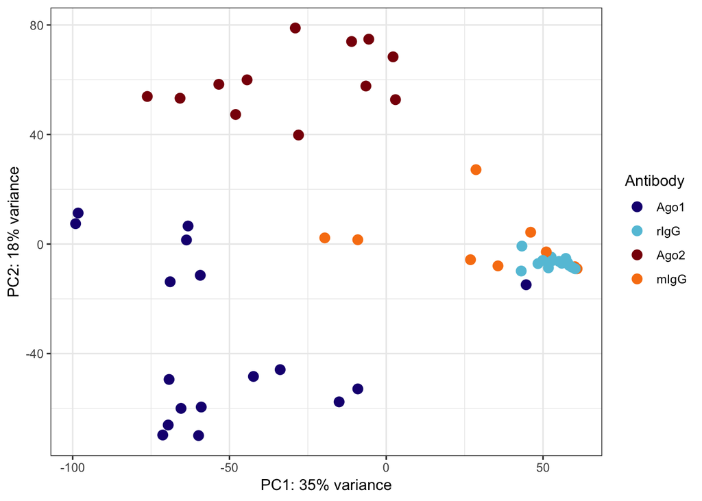

```r
Aag2x <- Aag2[m_cells]

dds_Aag2 <- DESeqDataSetFromMatrix(countData = Aag2x, colData = cell_samples, design = ~ Experiment + Antibody)

dds_Aag2 <- estimateSizeFactors(dds_Aag2,type="poscounts")

Aag2_rld <- varianceStabilizingTransformation(dds_Aag2)

b <-  plotPCA(Aag2_rld,intgroup=c("Experiment", "Antibody"), ntop=1E6, returnData=TRUE)

#reorder levels so can set colors
b$Antibody <- factor(b$Antibody, levels = c("Ago1","rIgG",  "Ago2", "mIgG"))
#set PC2 to be consistent with all unfiltered PCA
b$PC2 <- (b$PC2)*-1
#calculate variation as a rounded percent
percentVar <- round(100 * attr(b, "percentVar"))

ggplot(b, aes(x = PC1, y = PC2, color = Antibody, label=name)) +
geom_point(size =3) +
scale_color_manual(values =c("#1B0B80", "#64C3DB", "#8A0F09", "#F87F11"), name="Antibody") +
xlab(paste0("PC1: ", percentVar[1], "% variance")) +
ylab(paste0("PC2: ", percentVar[2], "% variance")) + theme_bw()
```

## *aegypti* PCA, Figure 4J

```r
aegypti_samples <- subset(all_samples, all_samples$Lysate=="aegypti")
aegypti_samples$Lysate <- NULL

#have 2 IgG samples with all zeros - need to drop or will give an error in the PCA
drop <- c("KRG092419_aegypti_mIgG_Exp7A", "KRG092419_aegypti_mIgG_Exp7B")
aegypti_samples <- aegypti_samples[!rownames(aegypti_samples) %in% drop, ]
m_aegypti <- row.names(aegypti_samples)

#check sample names match
m_aegypti %in% colnames(aegypti)
```

```
##  [1] TRUE TRUE TRUE TRUE TRUE TRUE TRUE TRUE TRUE TRUE TRUE TRUE TRUE TRUE
## [15] TRUE TRUE TRUE TRUE TRUE TRUE TRUE TRUE TRUE TRUE TRUE TRUE TRUE TRUE
## [29] TRUE TRUE TRUE TRUE TRUE TRUE TRUE TRUE TRUE TRUE TRUE
```

```r
aegypti_x <- aegypti[m_aegypti]

dds_aegypti <- DESeqDataSetFromMatrix(countData = aegypti_x, colData = aegypti_samples, design = ~ Experiment + Antibody) #
```

```
## factor levels were dropped which had no samples
```

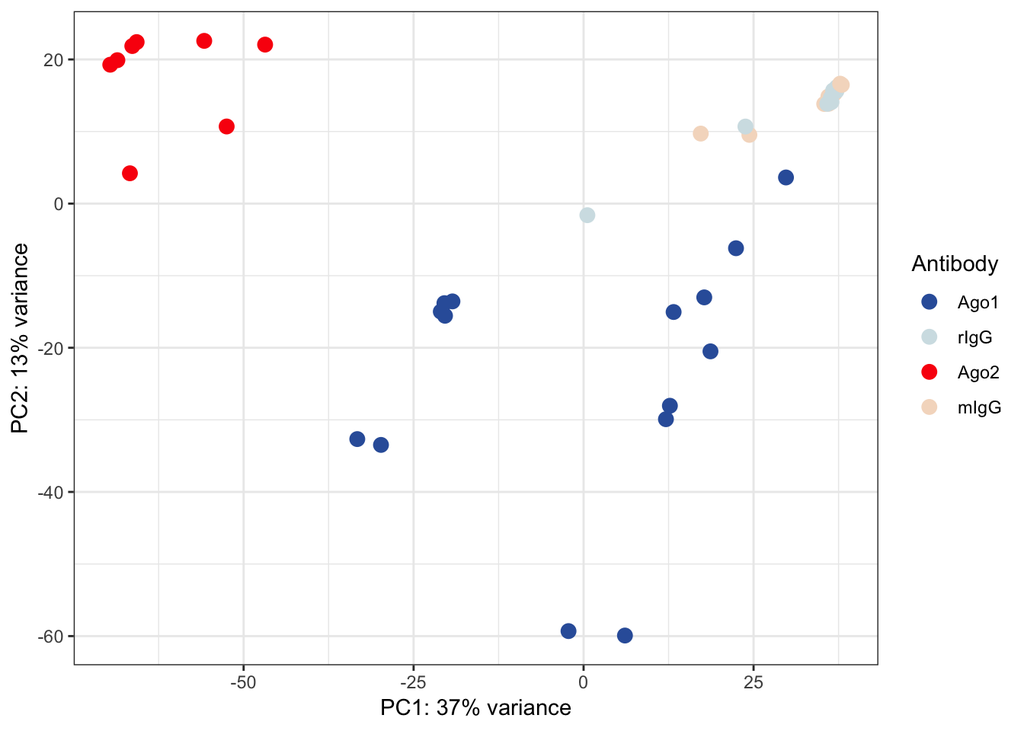

```r
dds_aegypti  <- estimateSizeFactors(dds_aegypti, type="poscounts")

rld_aegypti <- varianceStabilizingTransformation(dds_aegypti)

d <-  plotPCA(rld_aegypti ,intgroup=c("Experiment", "Antibody"), ntop=10^6, returnData=TRUE)

#reorder levels so can set colors
d$Antibody <- factor(d$Antibody, levels = c("Ago1","rIgG",  "Ago2", "mIgG"))
#set PC2 to be consistent with all unfiltered PCA
d$PC2 <- (d$PC2)*-1
#calculate variation as a rounded percent
percentVar <- round(100 * attr(d, "percentVar"))


ggplot(d, aes(x = PC1, y = PC2, color = Antibody, label=name)) +
geom_point(size =3) +
scale_color_manual(values =c("#3360A9", "#D2E1E5", "#FA0F0C", "#F4DBC7"), name="Antibody") +
xlab(paste0("PC1: ", percentVar[1], "% variance")) +
ylab(paste0("PC2: ", percentVar[2], "% variance")) + theme_bw()
```

## fgsea of targeted genes/pathways that drive Ago1 and Ago seperation by PCA; Figures 4H, 4I, 4K, 4L and Table S6

AaegL5 LVP_AGWG genome fasta and gtf is available for download at [Vectorbase](https://vectorbase.org/vectorbase/app/downloads/)

```r
gtffile <- "/Users/kathryn/Aedes-aegypti-LVP_AGWG_BASEFEATURES_AaegL5.2.gtf"

TxDb <- makeTxDbFromGFF(gtffile)
```

```
## Import genomic features from the file as a GRanges object ... OK
## Prepare the 'metadata' data frame ... OK
## Make the TxDb object ...
```

```
## OK
```

```r
test <- exonsBy(TxDb, use.names = TRUE)

#simplified names of chromosomes to match TxDB or gives and error
AaegL5 <- readDNAStringSet("/Users/kathryn/mirdeep2_master/Aedes-aegypti-LVP_AGWG_CHROMOSOMES_AaegL5_fixed.fa", format = "fasta", nrec=-1L)
tx <- AaegL5[test]

#writeXStringSet(tx, "/Users/kathryn/Reprocess_all_paper_datasets/alltranscripts.fa", format = "fasta")
```

output file “alltranscripts.fa.zip” is available in my [Github](https://github.com/kathrynrozengagnon/AGOCLIP_2020)  
This fasta of all transcript sequences was uploaded to [eggNOG-mapper v2](http://eggnog-mapper.embl.de/) to map geneIDs to annotations and GO terms  
“job_MM_e0ep_7ci_annotations.tsv” annotation tsv is available in my [Github](https://github.com/kathrynrozengagnon/AGOCLIP_2020)

```r
tsv <- read.delim("/Users/kathryn/Reprocess_all_paper_datasets/job_MM_e0ep_7ci_annotations.tsv", header = FALSE, sep ="\t",comment.char = "",skip = 4)
tsvv <- tsv %>% dplyr::select(V1,V7) %>% dplyr::mutate(Gene=gsub("-..","",V1)) %>% dplyr::select(-V1)
tsvvGOs <- as.vector(tsvv$V7)
names(tsvvGOs) <- paste0(tsvv$Gene,"_")

temp <- strsplit(tsvvGOs,",") %>% unlist
newFrame <- data.frame(ID=gsub("_.*","",names(temp)),GO=unname(temp))
temp <- newFrame %>% group_by(GO) %>% dplyr::mutate(newGO=paste(ID,sep=",",collapse=";"))

gt <- lapply(unique(newFrame$GO),function(x)unique(as.vector(newFrame[newFrame$GO %in% x,"ID"])))
names(gt) <- unique(newFrame$GO)

#get PCA loadings for PC2 by peak for Aag2
myRotation <- prcomp(t(assay(Aag2_rld)))$rotation
nflkflerf <- GRanges(gsub("_","-",rownames(myRotation)))
mcols(nflkflerf) <- data.frame(Names=rownames(myRotation),myRotation)
Aag2_noNA <- Aag2[!is.na(Aag2$annotation),]
mergeAag2 <- merge(Aag2_noNA, nflkflerf, by.x="peakID", by.y="Names", all.x = TRUE)
mergeAag2$PC2 <- (mergeAag2$PC2)*-1
eff <- mergeAag2[order(abs(mergeAag2$PC2),decreasing = TRUE),]
eff <- eff[match(unique(eff$geneId),eff$geneId),]
#write.table(eff,"/Users/kathryn/Reprocess_all_paper_datasets/GO_analysis/Aag2_merged_PC2_selected_peaks_unique_genes.txt",quote = FALSE, sep = "\t", col.names = TRUE ) #table available upon request
myStats <- eff$PC2
names(myStats) <- eff$geneId
fef <- fgsea(pathways = gt,
             stats=myStats,nperm = 1000)

ewfwe <- lapply(as.list(GOTERM),Term) %>% unlist
dvsvs <- data.frame(names(ewfwe),unname(ewfwe))
colnames(dvsvs) <- c("pathway","Term")

sdvcAag2 <- merge(fef,dvsvs,by="pathway",all.x=TRUE) %>% arrange(pval)
sdvcAag2$leadingEdge <- unlist(lapply(sdvcAag2$leadingEdge,function(x)paste0(x, collapse=":")))
sdvcAag2 <- sdvcAag2[order(sdvcAag2$NES,decreasing = TRUE),]
#have many pathways with exactly the same leading edge genes - for these, all p-values, NES, and sizes are exactly the same, so collapse

testAag2 <- sdvcAag2 %>% dplyr::group_by(leadingEdge) %>% dplyr::top_n(1, NES) %>% dplyr::summarise(Term = paste0(Term, collapse=","),pval=dplyr::first(pval),size= dplyr::first(size), NES =dplyr::first(NES)) #this is Supplementary Table 6, cells

#get PCA loadings for PC2 by peak for aegypti
myRotation <- prcomp(t(assay(rld_aegypti)))$rotation
aegypti_noNA <- aegypti[!is.na(aegypti$annotation),]
mergeaegypti <- merge(aegypti_noNA, nflkflerf, by.x="peakID", by.y="Names", all.x = TRUE)
mergeaegypti$PC2 <- (mergeaegypti$PC2)*-1
eff <- mergeaegypti[order(abs(mergeaegypti$PC2),decreasing = TRUE),]
eff <- eff[match(unique(eff$geneId),eff$geneId),]

#write.table(eff,"/Users/kathryn/Reprocess_all_paper_datasets/GO_analysis/aegypti_merged_PC2_selected_peaks_unique_genes.txt",quote = FALSE, sep = "\t", col.names = TRUE ) # table available upon request
myStats <- eff$PC2
names(myStats) <- eff$geneId
fef <- fgsea(pathways = gt,
             stats=myStats,nperm = 1000)
sdvcaegypti <- merge(fef,dvsvs,by="pathway",all.x=TRUE) %>% arrange(pval)
sdvcaegypti$leadingEdge <- unlist(lapply(sdvcaegypti$leadingEdge,function(x)paste0(x, collapse=":")))
sdvcaegypti <- sdvcaegypti[order(sdvcaegypti$NES,decreasing = TRUE),]
#have many pathways with exactly the same leading edge genes - for these, all p-values, NES, and sizes are exactly the same, so collapse

testaegypti <- sdvcaegypti %>% group_by(leadingEdge) %>% top_n(1, NES) %>% dplyr::summarise(Term = paste0(Term, collapse=","),pval=dplyr::first(pval),size=dplyr::first(size), NES =dplyr::first(NES)) #this is Supplementary Table 6,  aegypti
```

## Make annotation pie charts on final filtered peaks, Figures 4C-4F

```r
aegypti_Ago2GR <- makeGRangesFromDataFrame(aegypti_Ago2_filt,
                                     keep.extra.columns=FALSE,
                                     ignore.strand=FALSE,
                                     seqinfo=NULL,
                                     seqnames.field="seqnames",
                                     start.field="start",
                                     end.field="end",
                                     strand.field="strand",
                                     starts.in.df.are.0based=FALSE)

aegypti_Ago2anno <- annotatePeak(aegypti_Ago2GR,
                              TxDb=TxDb,
                              sameStrand=FALSE,
                              genomicAnnotationPriority = c("3UTR", "5UTR", "Exon",
                                                            "Intron", "Promoter", "Downstream", "Intergenic"),
                              overlap = "all")
```

```
## >> preparing features information...      2021-03-16 17:15:09
## >> identifying nearest features...        2021-03-16 17:15:09
```

```
## >> calculating distance from peak to TSS...   2021-03-16 17:15:09
## >> assigning genomic annotation...        2021-03-16 17:15:09
```

```
## >> assigning chromosome lengths           2021-03-16 17:15:13
## >> done...                    2021-03-16 17:15:13
```

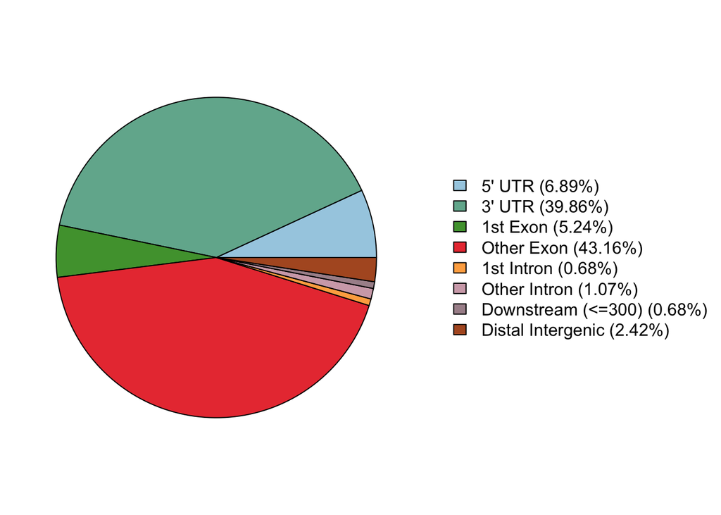

```r
plotAnnoPie(aegypti_Ago2anno)
```

```r
aegypti_Ago1GR <- makeGRangesFromDataFrame(aegypti_Ago1_filt,
                                           keep.extra.columns=FALSE,
                                           ignore.strand=FALSE,
                                           seqinfo=NULL,
                                           seqnames.field="seqnames",
                                     start.field="start",
                                     end.field="end",
                                     strand.field="strand",
                                           starts.in.df.are.0based=FALSE)

aegypti_Ago1GRanno <- annotatePeak(aegypti_Ago1GR,
                                 TxDb=TxDb,
                                 sameStrand=FALSE,
                                 genomicAnnotationPriority = c("3UTR", "5UTR", "Exon",
                                                               "Intron", "Promoter", "Downstream", "Intergenic"),
                                 overlap = "all")
```

```
## >> preparing features information...      2021-03-16 17:15:13
## >> identifying nearest features...        2021-03-16 17:15:13
```

```
## >> calculating distance from peak to TSS...   2021-03-16 17:15:14
## >> assigning genomic annotation...        2021-03-16 17:15:14
```

```
## >> assigning chromosome lengths           2021-03-16 17:15:14
## >> done...                    2021-03-16 17:15:14
```

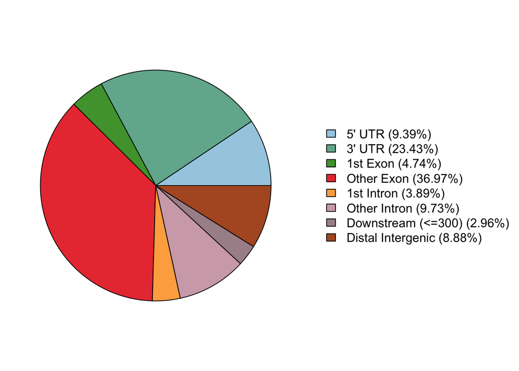

```r
plotAnnoPie(aegypti_Ago1GRanno)
```

```r
cells_Ago1GR <- makeGRangesFromDataFrame(Aag2_Ago1_filt,
                                           keep.extra.columns=FALSE,
                                           ignore.strand=FALSE,
                                           seqinfo=NULL,
                                           seqnames.field="seqnames",
                                     start.field="start",
                                     end.field="end",
                                     strand.field="strand",
                                           starts.in.df.are.0based=FALSE)

cells_Ago1anno <- annotatePeak(cells_Ago1GR,
                                 TxDb=TxDb,
                                 sameStrand=FALSE,
                                 genomicAnnotationPriority = c("3UTR", "5UTR", "Exon",
                                                               "Intron", "Promoter", "Downstream", "Intergenic"),
                                 overlap = "all")
```

```
## >> preparing features information...      2021-03-16 17:15:15
## >> identifying nearest features...        2021-03-16 17:15:15
```

```
## >> calculating distance from peak to TSS...   2021-03-16 17:15:15
## >> assigning genomic annotation...        2021-03-16 17:15:15
```

```
## >> assigning chromosome lengths           2021-03-16 17:15:15
## >> done...                    2021-03-16 17:15:15
```

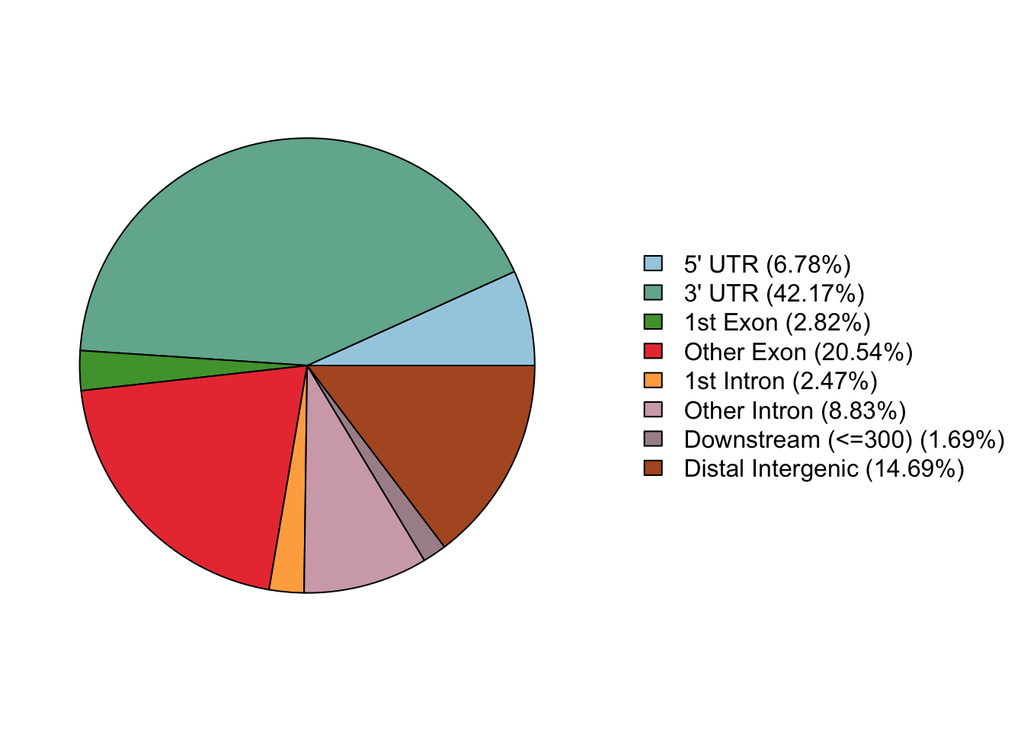

```r
plotAnnoPie(cells_Ago1anno)
```

```r
cells_Ago2GR <- makeGRangesFromDataFrame(Aag2_Ago2_filt,
                                           keep.extra.columns=FALSE,
                                           ignore.strand=FALSE,
                                           seqinfo=NULL,
                                           seqnames.field="seqnames",
                                     start.field="start",
                                     end.field="end",
                                     strand.field="strand",
                                           starts.in.df.are.0based=FALSE)

cells_Ago2anno <- annotatePeak(cells_Ago2GR,
                                 TxDb=TxDb,
                                 sameStrand=FALSE,
                                 genomicAnnotationPriority = c("3UTR", "5UTR", "Exon",
                                                               "Intron", "Promoter", "Downstream", "Intergenic"),
                                 overlap = "all")
```

```
## >> preparing features information...      2021-03-16 17:15:16
## >> identifying nearest features...        2021-03-16 17:15:16
```

```
## >> calculating distance from peak to TSS...   2021-03-16 17:15:16
## >> assigning genomic annotation...        2021-03-16 17:15:16
```

```
## >> assigning chromosome lengths           2021-03-16 17:15:16
## >> done...                    2021-03-16 17:15:16
```

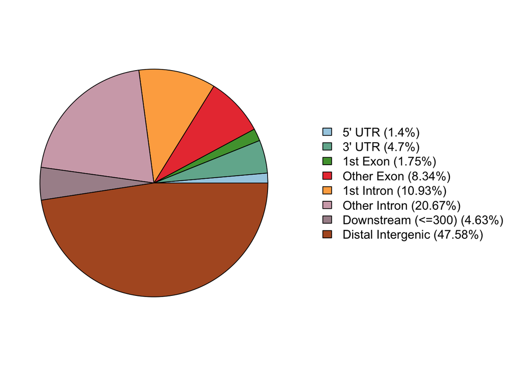

```r
plotAnnoPie(cells_Ago2anno)
```

## Now do Venn Diagrams to compare genes in different filtered ab/lysate combinations, Figure S3E

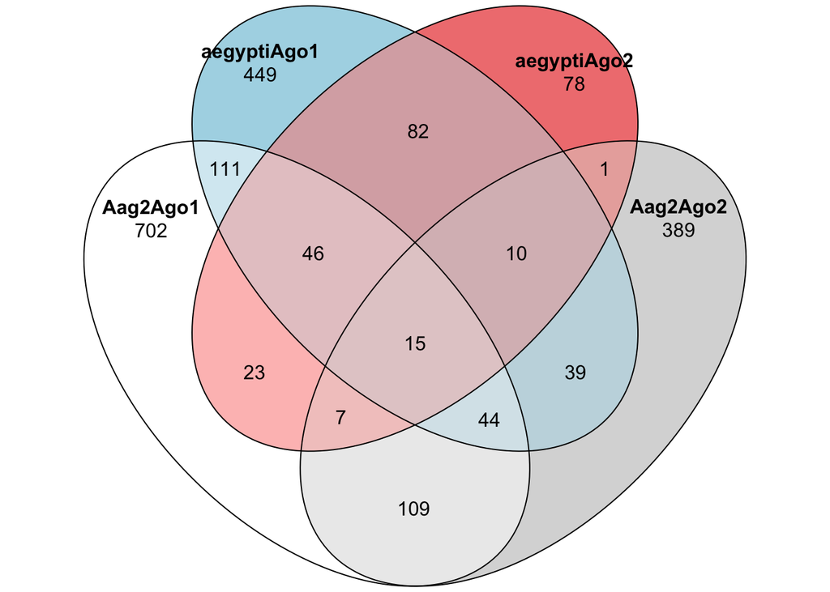

```r
#make list of unique genes in filtered
AA1 <- unique(subset(all$geneId, all$peakID %in% Aag2_Ago1_filt$peakID))
#remove NA, because not all peaks could be annotated to a gene
AA1 <- AA1[!is.na( AA1)]
AA2 <- unique(subset(all$geneId, all$peakID %in% Aag2_Ago2_filt$peakID))
AA2 <- AA2[!is.na( AA2)]
AeA1 <- unique(subset(all$geneId, all$peakID %in% aegypti_Ago1_filt$peakID))
AeA1 <- AeA1[!is.na( AeA1)]
AeA2 <- unique(subset(all$geneId, all$peakID %in% aegypti_Ago2_filt$peakID))
AeA2 <- AeA2[!is.na(AeA2)]
filt <- list(Aag2Ago1 = AA1, Aag2Ago2 = AA2, aegyptiAgo1 = AeA1, aegyptiAgo2 = AeA2)

plot(venn(filt))
```

## Venn Diagram to compare genes found in Zhang et al. and my aegypti AGO1 genes, Figure S3H

input file is Dataset S03 from Zhang et al., 2017, and is also available in my [Github](https://github.com/kathrynrozengagnon/AGOCLIP_2020)

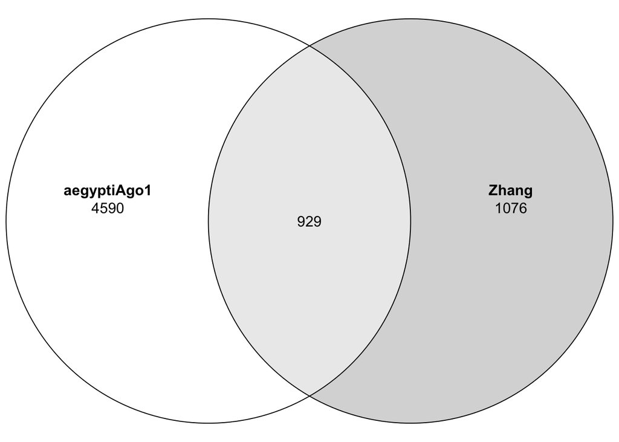

```r
Zhang <- read.delim("/Users/kathryn/Reprocess_all_paper_datasets/Zhang_peaks.txt", header = TRUE, sep = "\t")
reps <- grep("rep", colnames(Zhang), value = TRUE)
Zhang$all_counts <- rowSums(Zhang[reps])
#use their filtering criteria, at least one read/sample
Zhangfilt <-as.character(unique(subset(Zhang$annotation.ID, Zhang$all_counts > 6)))
Zhangfilt <- Zhangfilt[!is.na(Zhangfilt)]
AeA1 <- unique(subset(all$geneId, all$aegyptiAgo1_counts > 8))
AeA1 <- AeA1[!is.na( AeA1)]
compare <- list(aegyptiAgo1 = AeA1, Zhang = Zhangfilt)
plot(venn(compare))
```